# Reproducible Research: Peer Assessment 1

## Loading and preprocessing the data

1. Load the data (i.e. read.csv())

```r
temp <- tempfile()
download.file('https://raw.githubusercontent.com/luizvargaz/RepData_PeerAssessment1/master/activity.zip', temp, mode = 'wb')
unzip(temp, 'activity.csv')
rawData  <- read.csv('activity.csv', header = T)
head(rawData, 3)
```

```
##   steps       date interval
## 1    NA 2012-10-01        0
## 2    NA 2012-10-01        5
## 3    NA 2012-10-01       10
```

2. Process/transform the data (if necessary) into a format suitable for your analysis

```r
transRawData <- transform(rawData, date = as.Date(date))
str(transRawData)
```

```
## 'data.frame':    17568 obs. of  3 variables:
##  $ steps   : int  NA NA NA NA NA NA NA NA NA NA ...
##  $ date    : Date, format: "2012-10-01" "2012-10-01" ...
##  $ interval: int  0 5 10 15 20 25 30 35 40 45 ...
```

## What is mean total number of steps taken per day?

For this part of the assignment, you can ignore the missing values in the dataset.

```r
na <- is.na(transRawData$steps)
transRawData$esNA <- na
data <- transRawData[transRawData$esNA != 'TRUE',]
nrow(data)
```

```
## [1] 15264
```

1. Calculate the total number of steps taken per day

```r
dataDay <- aggregate(steps ~ date, data, FUN = 'sum')
print(dataDay)
```

```
##          date steps
## 1  2012-10-02   126
## 2  2012-10-03 11352
## 3  2012-10-04 12116
## 4  2012-10-05 13294
## 5  2012-10-06 15420
## 6  2012-10-07 11015
## 7  2012-10-09 12811
## 8  2012-10-10  9900
## 9  2012-10-11 10304
## 10 2012-10-12 17382
## 11 2012-10-13 12426
## 12 2012-10-14 15098
## 13 2012-10-15 10139
## 14 2012-10-16 15084
```

[output cut: 39 more lines]

2. If you do not understand the difference between a histogram and a barplot, research the difference between them. Make a histogram of the total number of steps taken each day

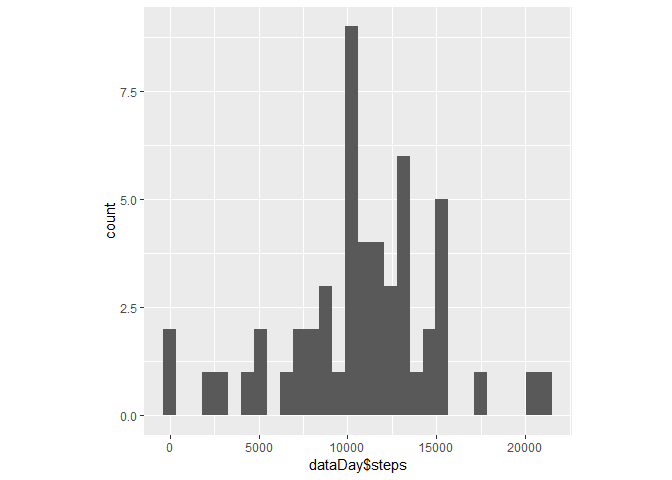

```r
library(ggplot2)
library(scales)
histSteps <- qplot(dataDay$steps, geom = 'histogram') + theme(aspect.ratio = 1)
print(histSteps)
```

```r
library(data.table)
dataDayT <- data.table(data)
#dataDayT[,list(mean = mean(steps), median = median(steps)), by = date]
dataDayT[,list(mean = mean(steps), median = median(steps))]
```

```
##       mean median
## 1: 37.3826      0
```

## What is the average daily activity pattern?

1. Make a time series plot (i.e. type = “l”) of the 5-minute interval (x-axis) and the average number of steps taken, averaged across all days (y-axis)

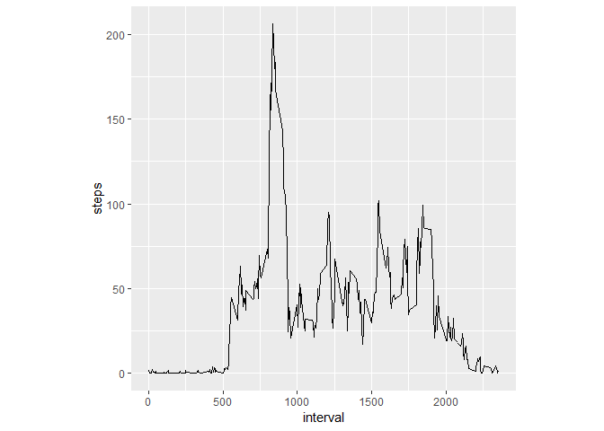

```r
dataSteps <- aggregate(steps ~ interval, data, FUN = 'mean')
graphTimeSteps <- qplot(interval, steps, data = dataSteps, geom = 'line') + theme(aspect.ratio = 1)
print(graphTimeSteps)
```

2. Which 5-minute interval, on average across all the days in the dataset, contains the maximum number of steps?

```r
apply(dataSteps, MARGIN = 2, function(x) max(x, na.rm = TRUE))
```

[output not shown]

## Imputing missing values

Note that there are a number of days/intervals where there are missing values (coded as NA). The presence of missing days may introduce bias into some calculations or summaries of the data.

1. Calculate and report the total number of missing values in the dataset (i.e. the total number of rows with NAs)

```r
length(which(is.na(rawData$steps)))
```

```
## [1] 2304
```

2. Devise a strategy for filling in all of the missing values in the dataset. The strategy does not need to be sophisticated. For example, you could use the mean/median for that day, or the mean for that 5-minute interval, etc.

```r
fillNa <- function(dataFrame){
        vectorinterval <- unique(dataFrame$interval)
        count <- 0
        for(i in vectorinterval){
                subsetInterval <- dataFrame[dataFrame$interval == i,]
                medianSteps <- mean(subsetInterval$steps, na.rm=TRUE)
                subsetInterval$steps[which(is.na(subsetInterval$steps))] <- medianSteps

                if(count == 0){
                        cleanData <- subsetInterval
                }else{
                        cleanData <- rbind(cleanData, subsetInterval)
                }

                count <- count + 1

        }
        newCleanData <- cleanData
}
```

3. Create a new dataset that is equal to the original dataset but with the missing data filled in

```r
newData <- fillNa(transRawData)
str(newData)
```

```
## 'data.frame':    17568 obs. of  4 variables:
##  $ steps   : num  1.72 0 0 47 0 ...
##  $ date    : Date, format: "2012-10-01" "2012-10-02" ...
##  $ interval: int  0 0 0 0 0 0 0 0 0 0 ...
##  $ esNA    : logi  TRUE FALSE FALSE FALSE FALSE FALSE ...
```

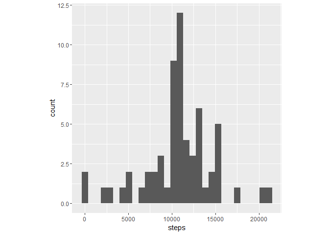

```r
library(ggplot2)
library(scales)
stepsByDay <- aggregate(steps ~ date, newData, FUN = 'sum')
newHistSteps <- qplot(steps, data = stepsByDay, geom = 'histogram') + theme(aspect.ratio = 1)
print(newHistSteps)
```

```r
newDataDayT <- data.table(newData)
#newDataDayT[,list(mean=mean(steps), median=median(steps)),by=date]
newDataDayT[,list(mean=mean(steps), median=median(steps))]
```

```
##       mean median
## 1: 37.3826      0
```

## Are there differences in activity patterns between weekdays and weekends?

For this part the weekdays() function may be of some help here. Use the dataset with the filled-in missing values for this part.

1. Create a new factor variable in the dataset with two levels - “weekday” and “weekend” indicating whether a given date is a weekday or weekend day.

```r
dataDays <- newData
dataDays$day <- weekdays(newData$date)
days <- unique(dataDays$day)

dataDaysWeekend <- dataDays[dataDays$day == 'Saturday' | dataDays$day == 'Sunday',]
lenWeekend <- nrow(dataDaysWeekend)
vectorWeekend <- rep('weekend', lenWeekend)
dataDaysWeekend$week <- vectorWeekend

dataDaysWeekday <- dataDays[dataDays$day == 'Tuesday' | dataDays$day == 'Thursday' | dataDays$day == 'Wednesday' | dataDays$day == 'Friday' | dataDays$day == 'Monday',]
lenWeekday <- nrow(dataDaysWeekday)
vectorWeekday <- rep('weekday', lenWeekday)
dataDaysWeekday$week <- vectorWeekday

dataWeek <- rbind(dataDaysWeekend, dataDaysWeekday)
```

2. Make a panel plot containing a time series plot (i.e. type = “l”) of the 5-minute interval (x-axis) and the average number of steps taken, averaged across all weekday days or weekend days (y-axis). See the README file in the GitHub repository to see an example of what this plot should look like using simulated data.

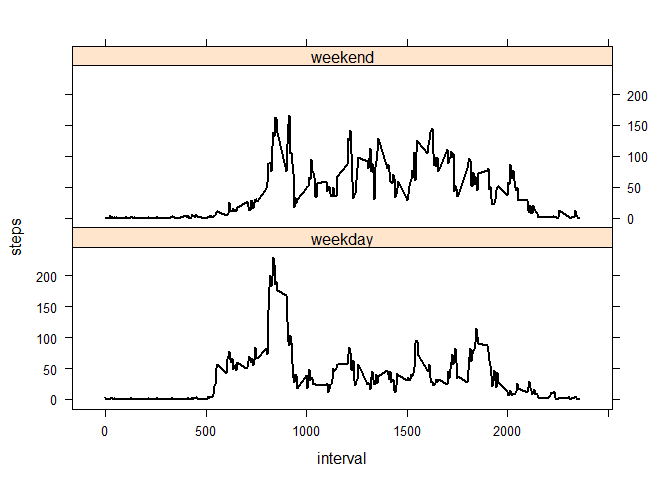

```r
d <- aggregate(steps ~ interval + week, dataWeek, FUN = 'mean')
library(lattice)
xyplot(steps ~ interval | factor(week),
       data = d,
       type = 'l',
       lwd = c(2, 1),
       col.line = 'black',
       layout=(c(1,2)))
```